Dans un premier temps, nous avons généré des nombres pseudo-aléatoires à l’aide de l’ensemble des générateurs dont vous retrouverez l’implémentation dans les annexes. Voici les résultats obtenus :

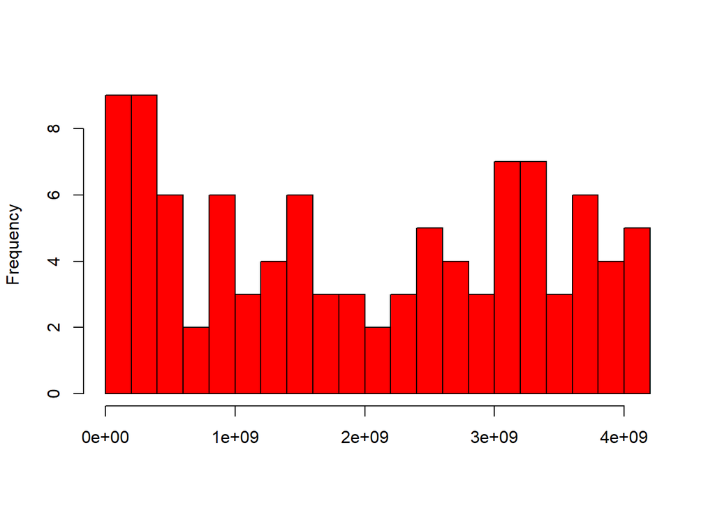

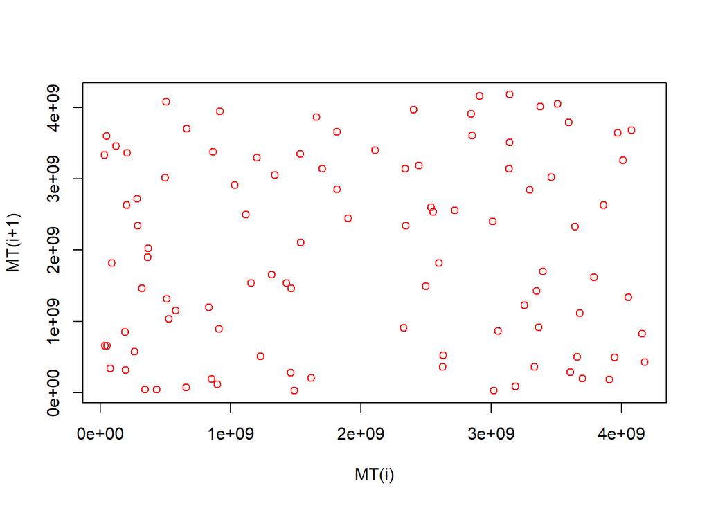

Générateur de Mersenne Twister (Graine : 1502, 100 générations)

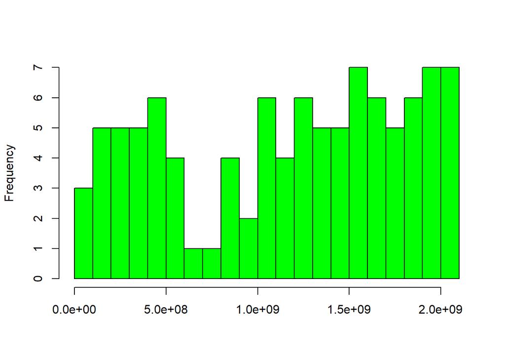

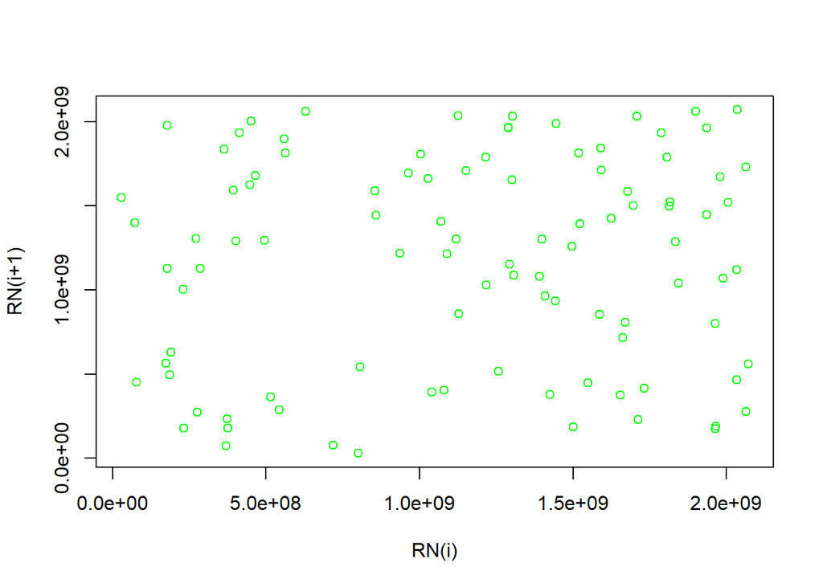

Générateur RANDU (Graine : 5645, 100 générations)

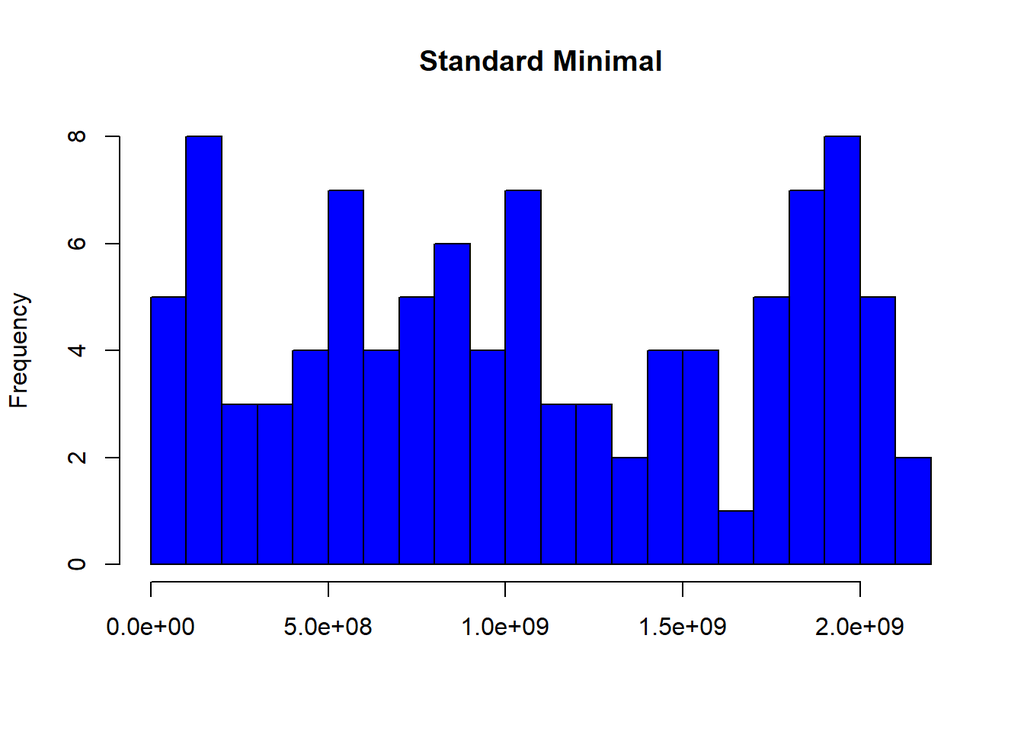

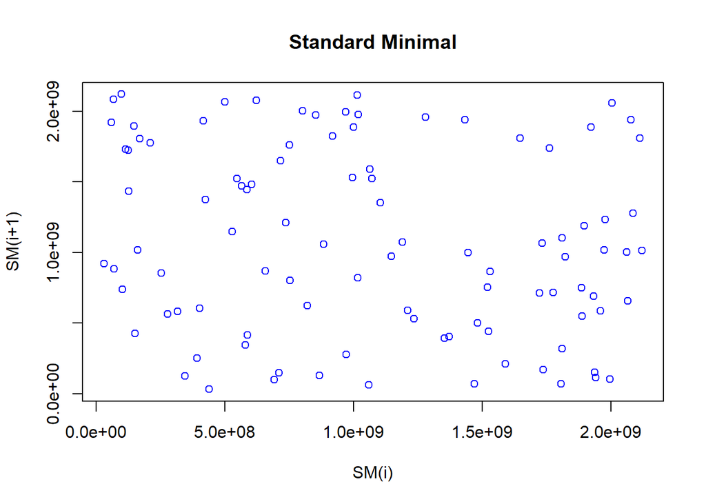

Générateur Standard Minimal (Graine : 9575, 100 générations)

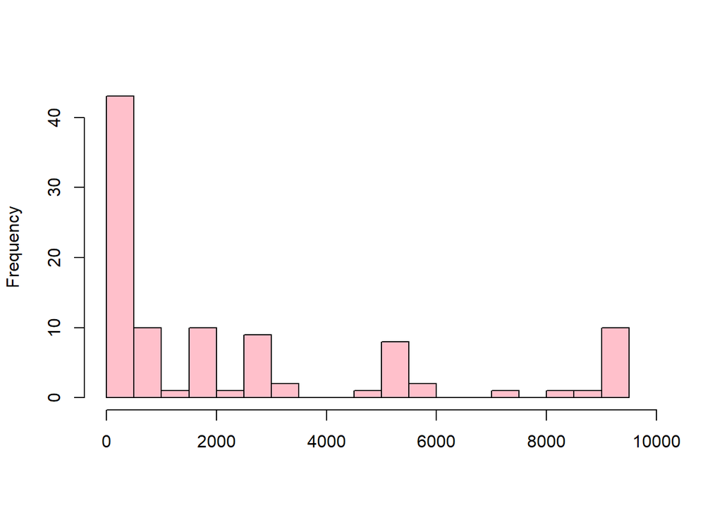

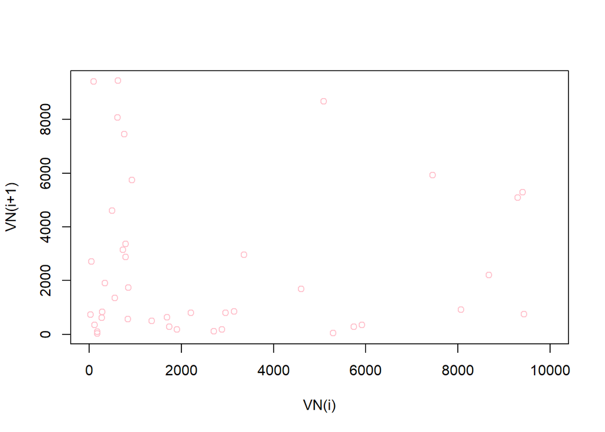

Générateur de Von Neuman (Graine : 3454, 100 générations)

Pour donner une vision d’ensemble, nous avons généré 100 séquences avec des graines produites par la fonction **sample** de R :

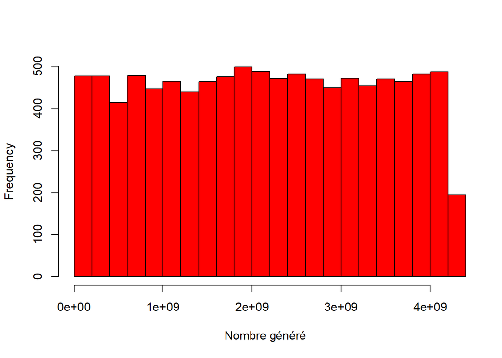

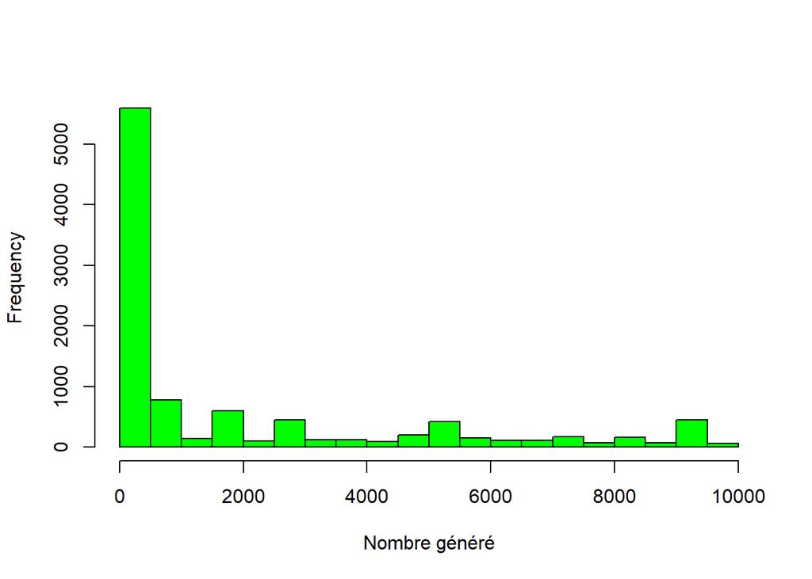

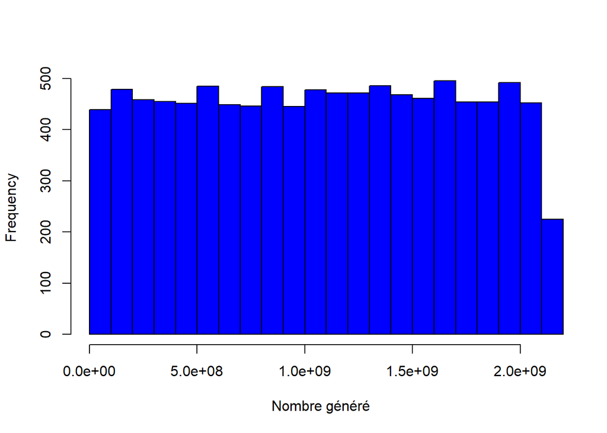

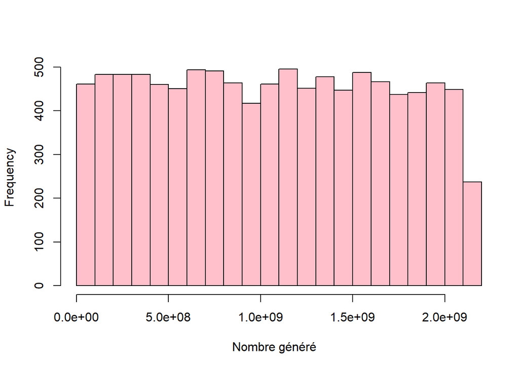

Etude sur 100 séquences de cardinal 100, Graine aléatoire

Dans l’ensemble, les nombres produits sont bien répartis sur les intervalles considérés à part pour Von Neuman, qui génère une majorité de nombres inférieurs à 2000. Mais cela n’est qu’une apréciation visuelle, par la suite nous allons effectuer divers tests sur nos générateurs afin de déterminer si les nombres et séquences produites peuvent êtres considérés comme aléatoires.

Les deux premières parties traitent de tests réalisés sur les bits des nombres générés.

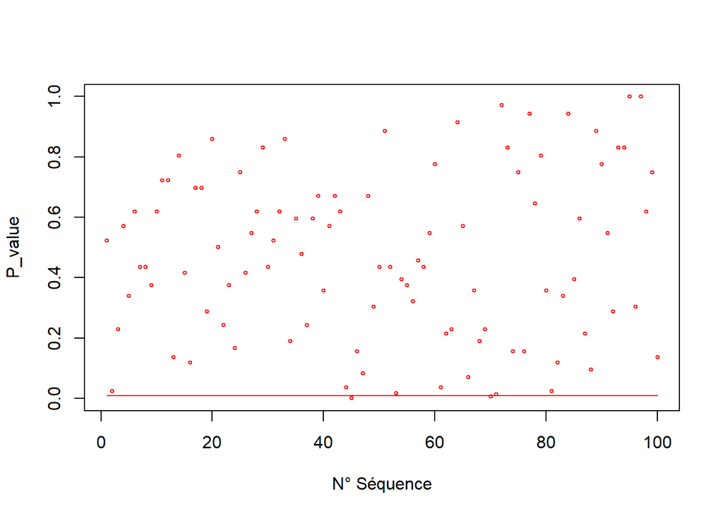

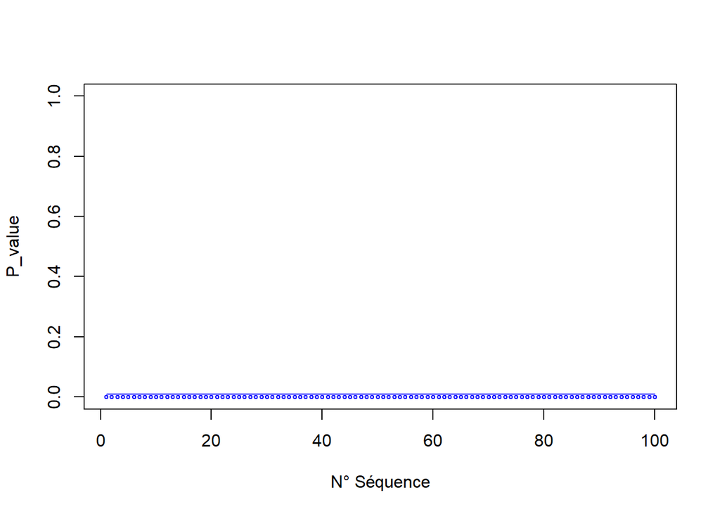

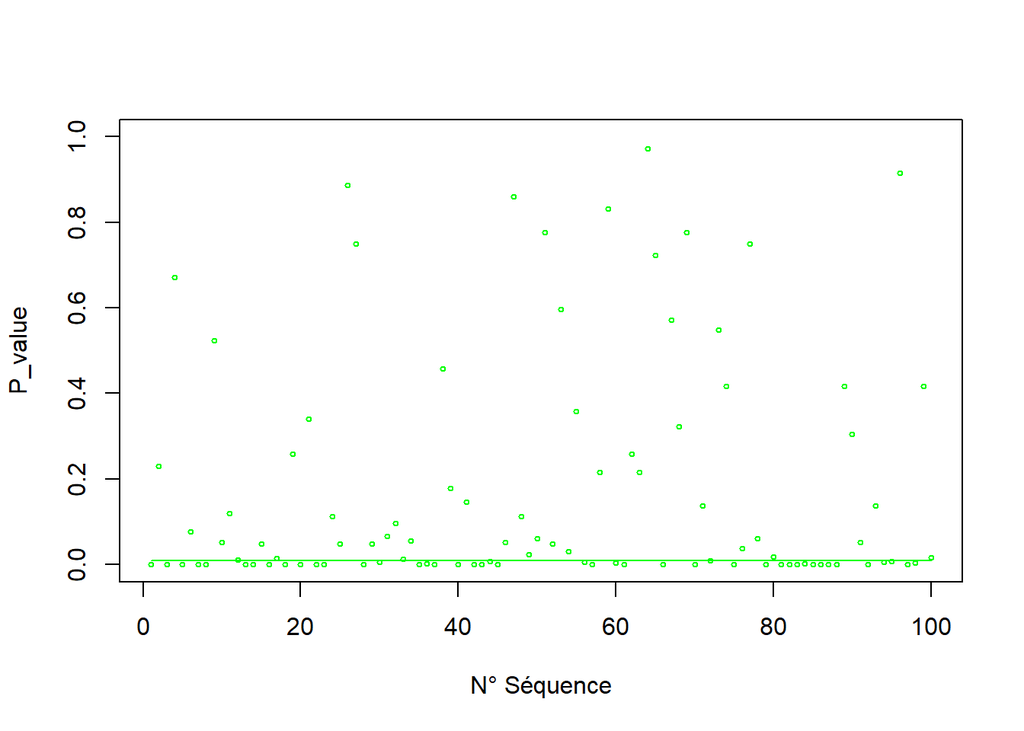

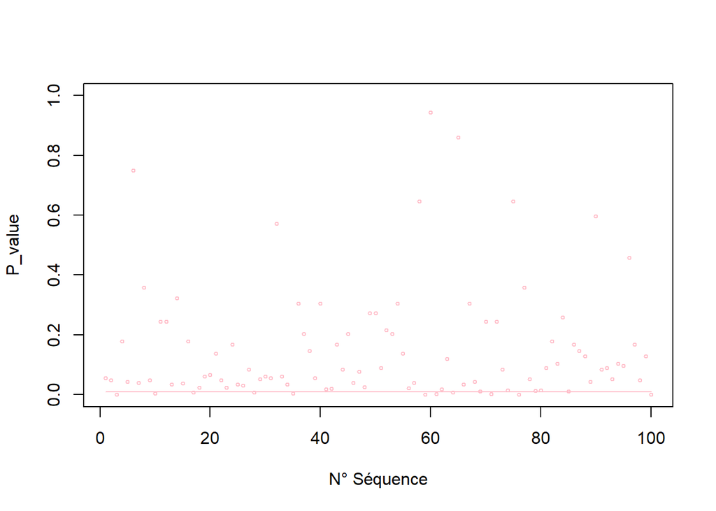

Etude de la répartition des bits sur 100 séquences de cardinal 100, Graines aléatoires

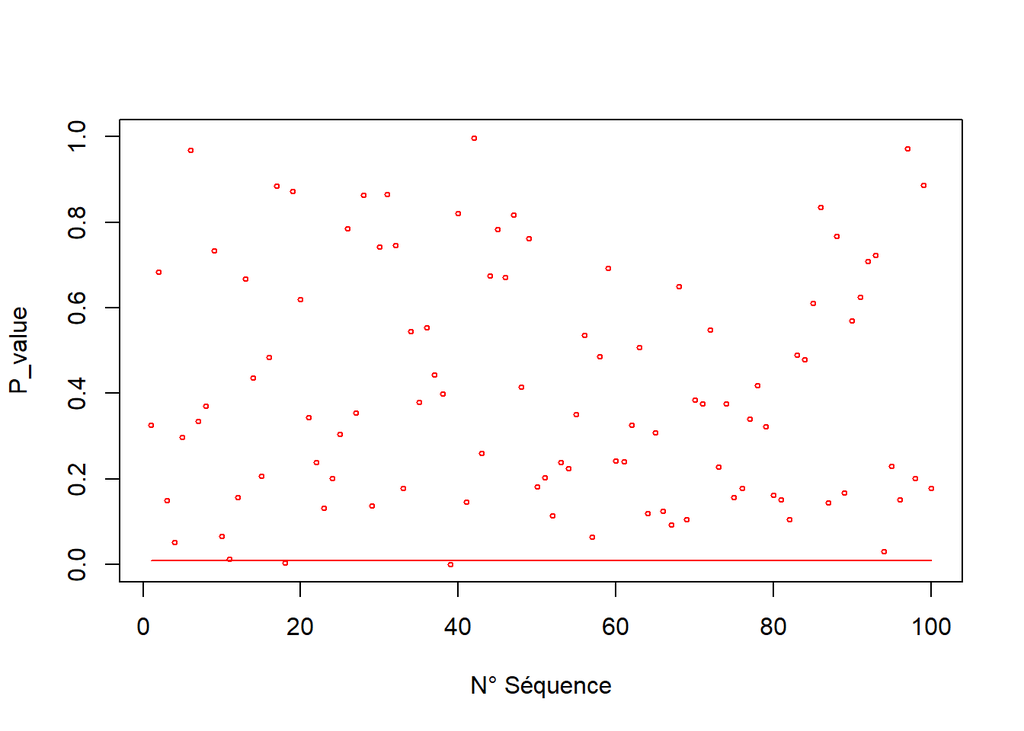

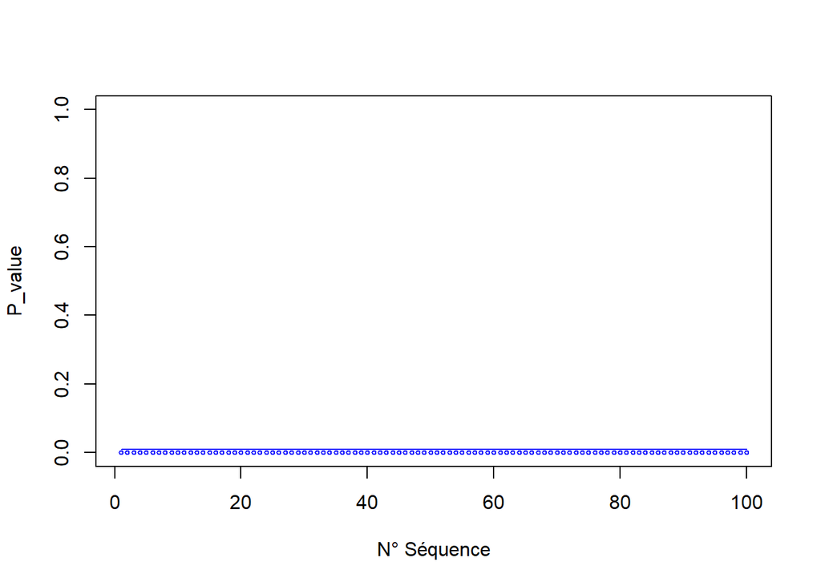

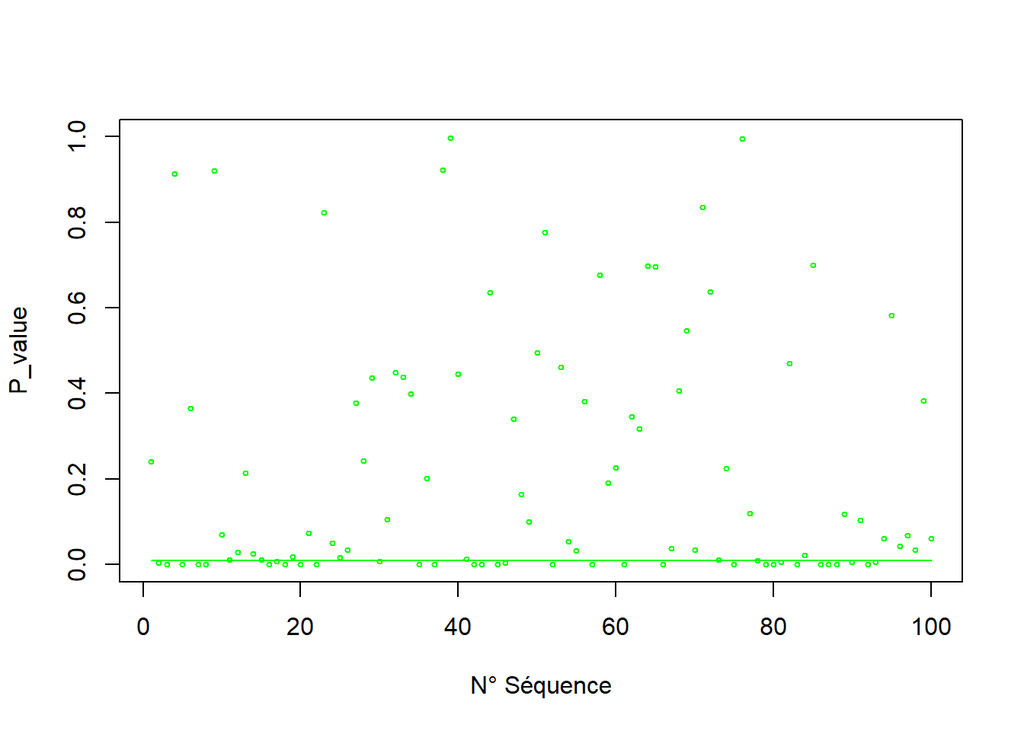

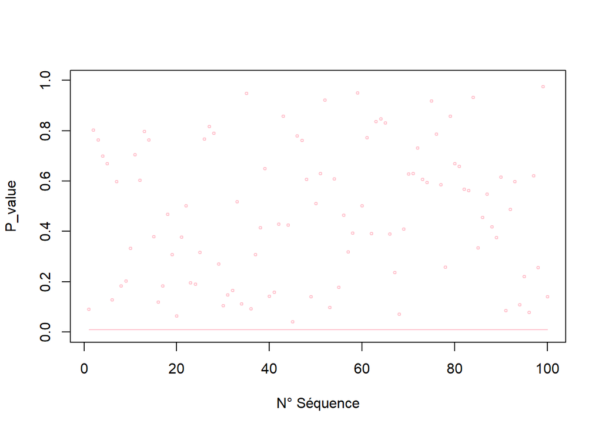

Etude de l’ordonnancement des bits sur 100 séquences de cardinal 100, Graines aléatoires

Ici nous nous intéressons aux nombres dans leur représentation décimale et vérifions si la séquence produite suit la loi uniforme (chaque nombre à autant de chance d’apparaître qu’un autre).

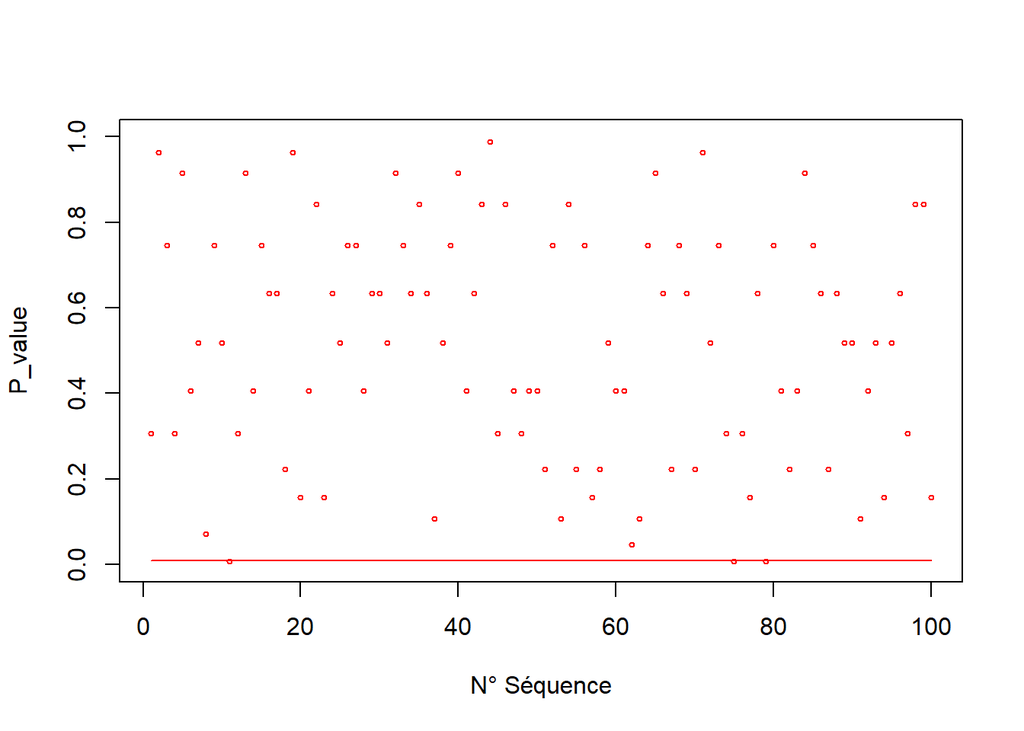

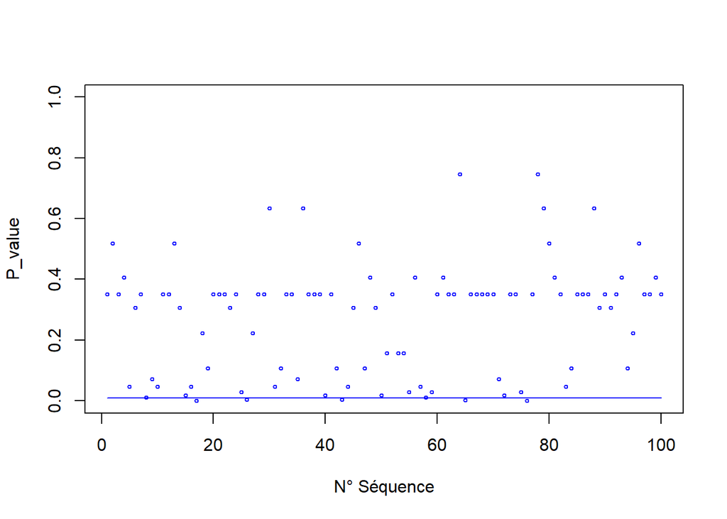

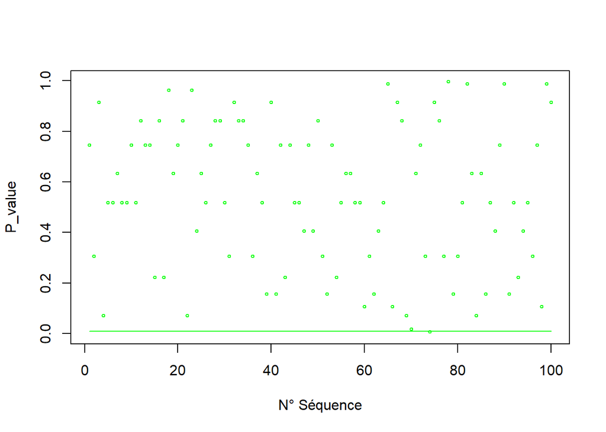

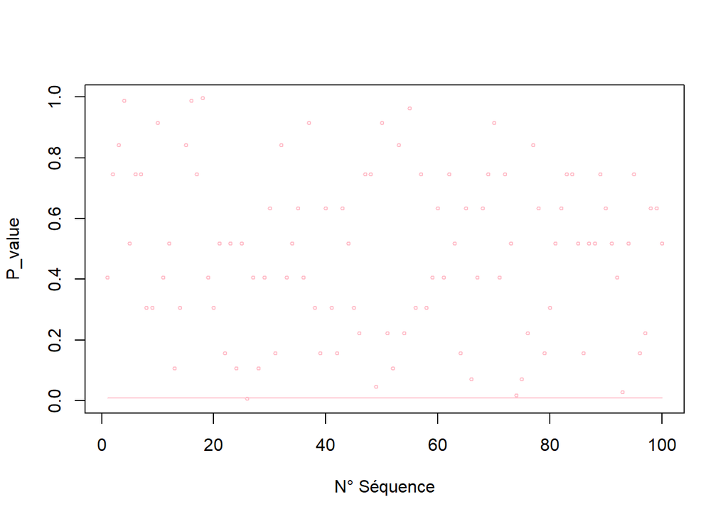

Etude de la loi uniforme sur 100 séquences de cardinal 100, Graines aléatoires

Nous allons visualiser l’évolution d’un système pendant une durée de 12 heures:

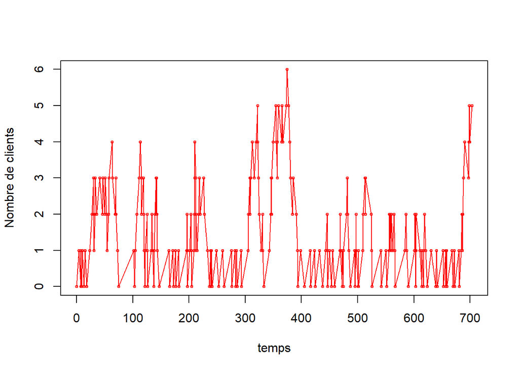

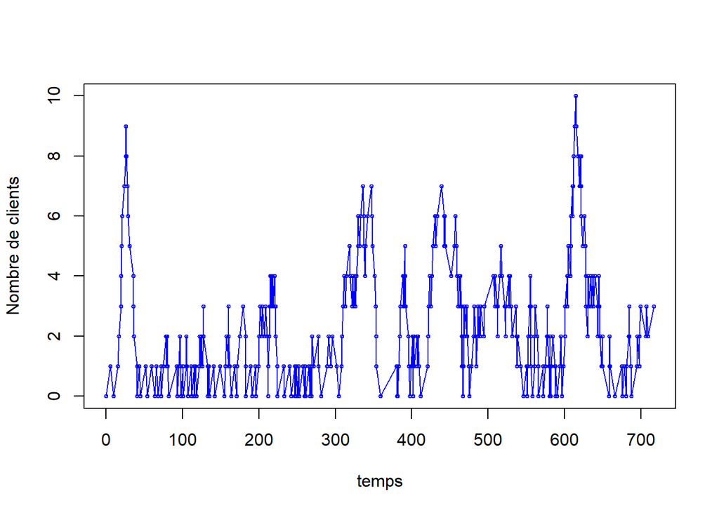

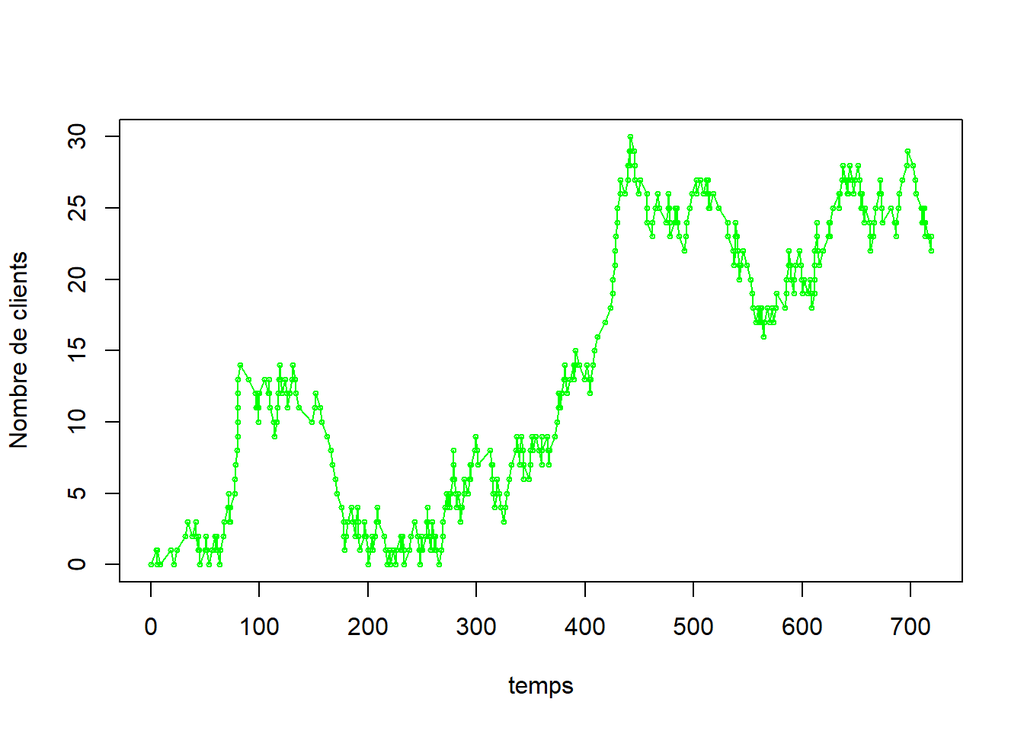

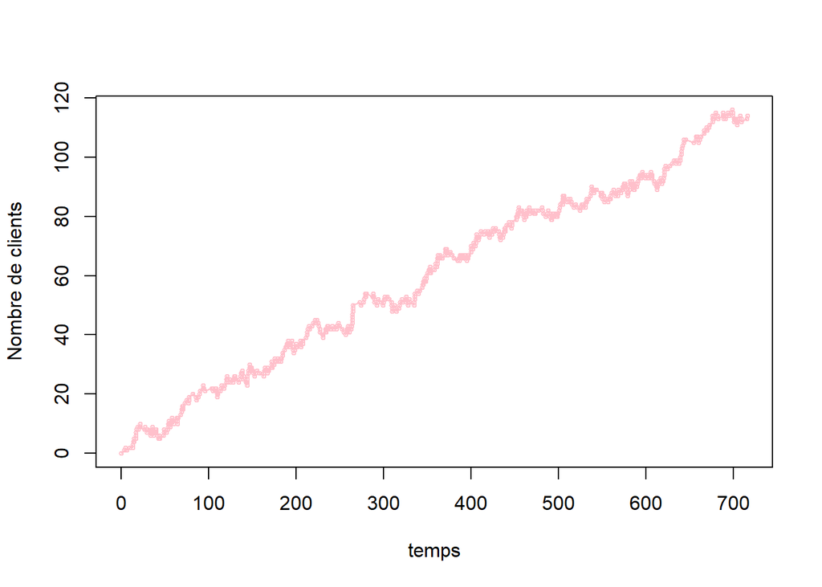

évolution du nombre de clients dans le système pendant 12 heures de fonctionnement

Etudions le rapport de notre file au modèle théorique.

```
## [1] "E(N)/E(W)= 0.188382800236516"
```

```
## [1] "lambda= 0.166666666666667"
```

```
## [1] "E(N)/E(W)= 0.278909960801243"
```

```
## [1] "lambda= 0.233333333333333"
```

```
## [1] "E(N)/E(W)= 0.290244679066078"
```

```
## [1] "lambda= 0.333333333333333"
```

```
## [1] "E(N)/E(W)= 0.364795324718151"
```

```
## [1] "lambda= 0.5"
```

```
## [1] "E(W)-E(Wa)= 2.95266325418264"
```

```
## [1] "E(W)-E(Wa)= 2.45577655634133"
```

```
## [1] "E(W)-E(Wa)= 3.26178478428427"
```

```
## [1] "E(W)-E(Wa)= 2.77888544302346"
```

```
## [1] "1/mu= 3"
```

```
## [1] "E(Na)/E(Wa) = 0.236889010414935"
```

```
## [1] "lambda = 0.166666666666667"
```

```
## [1] "E(W)-E(Wa) = 0.350261601553225"
```

```
## [1] "lambda = 0.233333333333333"
```

```
## [1] "E(W)-E(Wa) = 0.288268009374079"
```

```
## [1] "lambda = 0.333333333333333"
```

```
## [1] "E(W)-E(Wa) = 0.364053303633305"
```

```
## [1] "lambda = 0.5"
```

Nous allons visualiser l’évolution d’un système pendant une durée de 12 heures:

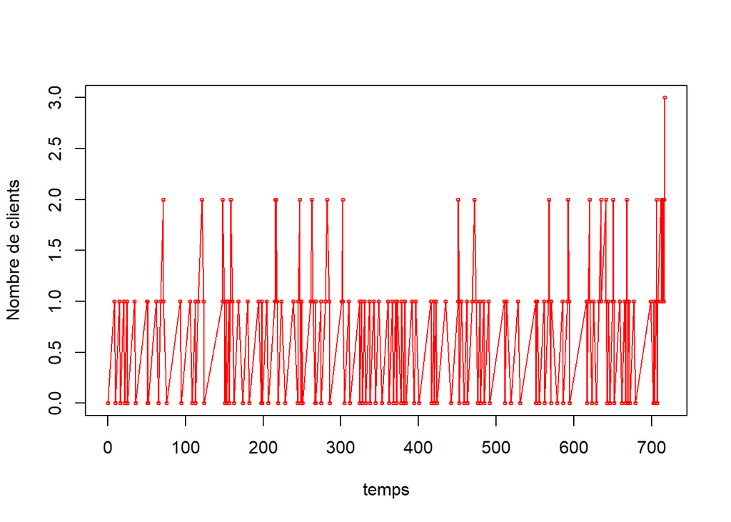

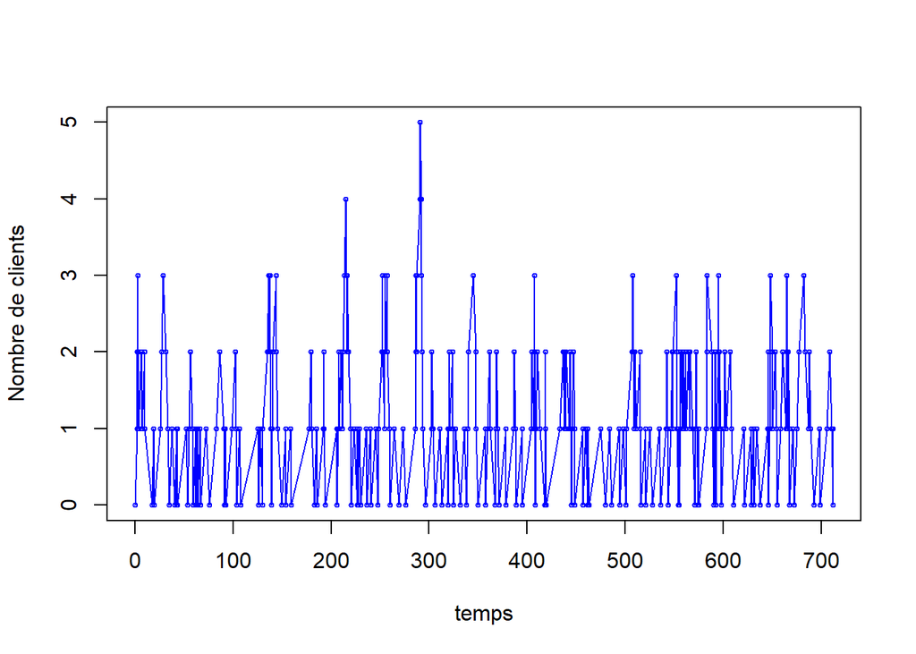

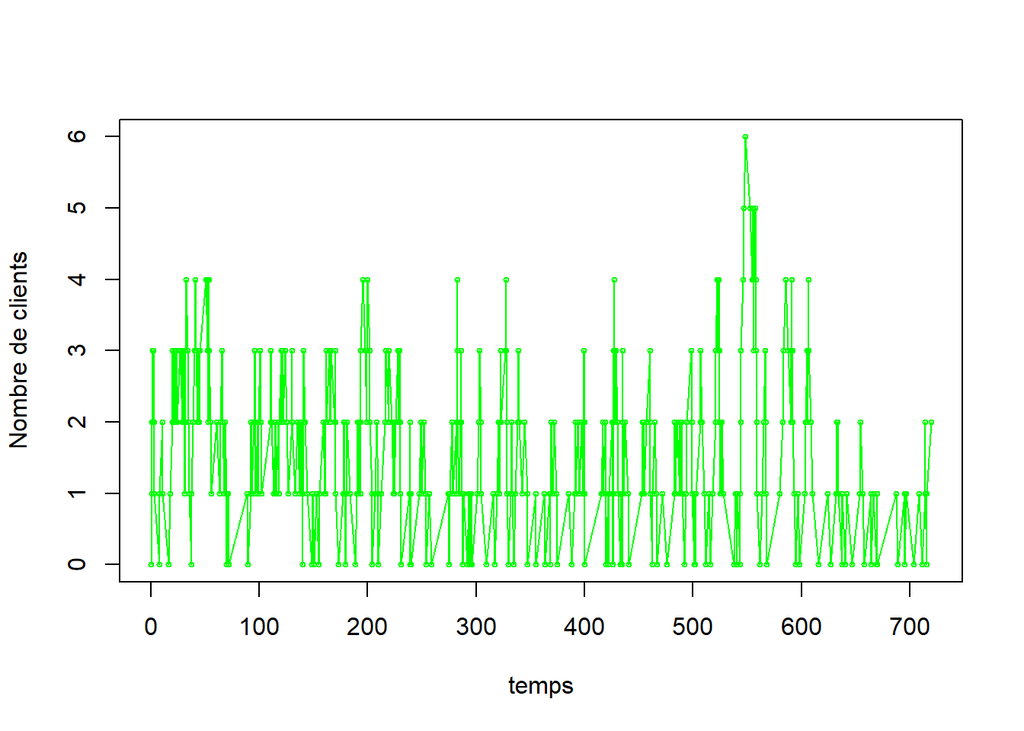

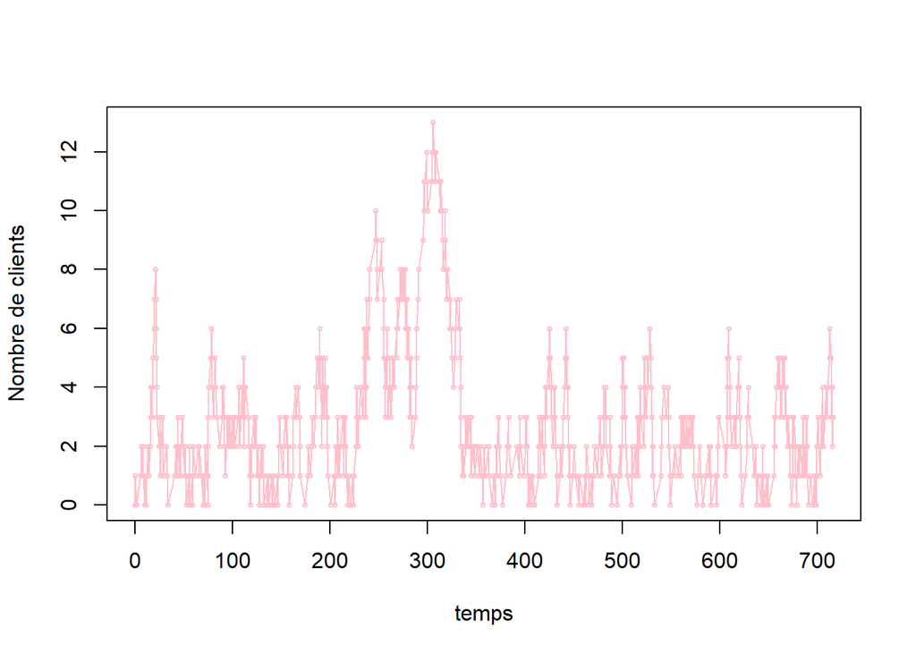

évolution du nombre de clients dans le système pendant 12 heures de fonctionnement

```r
VonNeumann <- function(n, p=1, graine)
{
  x <-  rep(graine,n*p+1)
  for(i in 2:(n*p+1))
  {
    numbers <- strsplit(format(x[i-1]^2,scientific=FALSE),'')[[1]]
    while(length(numbers)>4){
        numbers <- numbers[2:(length(numbers)-1)]
    }
    x[i] <- as.numeric(numbers)%*%(10^seq(length(numbers)-1,0,-1))
  }
  x <- matrix(x[2:(n*p+1)],nrow=n,ncol=p)
  return(x)
}
```

```r
MersenneTwister <- function(n, p=1, graine)
{
  set.seed(graine,kind='Mersenne-Twister')
  x <- sample.int(2^32-1,n*p)
  x <- matrix(x,nrow=n,ncol=p)
  return(x)
}
```

```r
RANDU <- function(n=1,k = 10,graine)
{
  x <-  rep(graine,k*n+1)
  for (i in 2:(k*n+1)) {
    x[i] <- (65539*x[i-1])%%(2^31)
  }
  x <- matrix(x[2:(k*n+1)],nrow=n,ncol=k)

  return(x)
}
```

```r
StandardMinimal <- function(n=1,k = 10,graine)
{
  x <-  rep(graine,k*n+1)

  for (i in 2:(k*n+1)) {
    x[i] <- (16807*x[i-1])%% (2^31-1)
  }

  x <- matrix(x[2:(k*n+1)],nrow=n,ncol=k)

  return(x)
}
```

```r
binary <- function(x)
{
  if((x<2^31)&(x>=0))
    return( as.integer(intToBits(as.integer(x))) )
  else{
    if((x<2^32)&(x>0))
      return( c(binary(x-2^31)[1:31], 1) )
    else{
      cat('Erreur dans binary : le nombre etudie n est pas un entier positif en 32 bits.\n')
      return(c())
    }
  }
}
```

[output not shown]

```r
Frequency <- function(x, nb)
{
  cn <- binary(x[1])
  b <- cn[1:nb]
  for(i in 2:length(x)){
    cn <- binary(x[i])
    b <- c(b,cn[1:nb])
  }
  for(i in 1:length(b)){
    if(b[i]==0)
      b[i] <- -1
  }

  S <- sum(b)

  sObs <- abs(S)/sqrt(length(b))

  p <- 2*(1-pnorm(sObs,0,1))

  return(p)
}
```

```r
Runs <- function(x, nb)
{
  cn <- binary(x[1])
  b <- cn[1:nb]
  for(i in 2:length(x)){
    cn <- binary(x[i])
    b <- c(b,cn[1:nb])
  }
  #Pre-test
  S <- sum(b)
  pi <- S/length(b)

  if(abs(pi-(1/2))>=(2/sqrt(length(b)))){
    return(0.0)
  }

  #Test
  VnObs <- 0
  for(i in 1:(length(b)-1)){
    if(b[i+1]!=b[i])
      VnObs <- VnObs + 1
  }
  VnObs <- VnObs + 1
  frac <- (abs(VnObs-2*length(b)*pi*(1-pi))/(2*sqrt(length(b))*pi*(1-pi)))
  P <- 2*(1-pnorm(frac,0,1))

  return(P)
}
```